# Statistics: The Science of Decisions Project Instructions

## Background Information

In a Stroop task, participants are presented with a list of words, with each word displayed in a color of ink. The participant’s task is to say out loud the color of the ink in which the word is printed. The task has two conditions: a congruent words condition, and an incongruent words condition. In the congruent words condition, the words being displayed are color words whose names match the colors in which they are printed: for example RED, BLUE. In the incongruent words condition, the words displayed are color words whose names do not match the colors in which they are printed: for example PURPLE, ORANGE. In each case, we measure the time it takes to name the ink colors in equally-sized lists. Each participant will go through and record a time from each condition.

## Questions For Investigation

As a general note, be sure to keep a record of any resources that you use or refer to in the creation of your project. You will need to report your sources as part of the project submission.

**1) What is our independent variable? What is our dependent variable?**

- The independent variable of the Stroop Task is the color of the words in both congruent and incongruent conditions.
- The dependent variable is the time to name the ink colors in equally-sized lists, in both conditions

**2) What is an appropriate set of hypotheses for this task? What kind of statistical test do you expect to perform? Justify your choices.**

- The null hypothesis is that the time to complete the list under the "congruent words condition" and the "incongruent words condition" is equal.
- The alternative hypothesis is that the time to complete the list under the "congruent words condition" will be less than under the "incongruent words condition". In general, it is reasonable expect that when the displayed words do not match the colors which they are printed the participants might be confused to some extent. For this reason it is more appropriate to select the previous alternative hypothesis over anything else.

The two hypotheses can be formalized in the following way:

1. $ H_0: \bar{\mu}_{C} = \bar{\mu}_{I} $
2. $ H_a: \bar{\mu}_{C} < \bar{\mu}_{I} $

Each participant has to complete the Stroop task under both conditions and thus the two samples are dependent. Moreover, they are random samples from a population for which the parameters $(\mu, \sigma)$ are unknown to us. This means that I am going to use a t-test for dependent means.

*Now it’s your chance to try out the Stroop task for yourself. Go to this link, which has a Java-based applet for performing the Stroop task. Record the times that you received on the task (you do not need to submit your times to the site.) Now, download this dataset which contains results from a number of participants in the task. Each row of the dataset contains the performance for one participant, with the first number their results on the congruent task and the second number their performance on the incongruent task.*

**3) Report some descriptive statistics regarding this dataset. Include at least one measure of central tendency and at least one measure of variability.**

I am going to compute and report the following descripive statistics:

- Central tendency:
  1. Average value (both samples)
  2. Median value (both samples)
  3. Point estimate
- Variability:
  1. Standard deviation (both samples)
  2. Range (both samples)
  3. Standard deviation of differences

Below is the code that I used to parse the dataset:

```python
import csv
import numpy as np

with open('/Users/kovanostra/Desktop/stroopdata.csv', 'rb') as csvfile:
    stroopTask = csv.reader(csvfile, delimiter=',')
    congruent = []
    incongruent = []
    for row in stroopTask:
        congruent.append(row[0])
        incongruent.append(row[1])
    congruent.pop(0)
    incongruent.pop(0)
    congruent = map(float,congruent)
    incongruent = map(float,incongruent)
```

### Central tendency measures

##### 1. Average value

```python
mean_cong = np.mean(congruent)
mean_incong = np.mean(incongruent)

print 'The average time that participants needed to name all the colors \
under the congruent condition was %.2f seconds\n' % mean_cong

print 'The average time that participants needed to name all the colors \
under the incongruent condition was %.2f seconds\n' % mean_incong
```

```
The average time that participants needed to name all the colors under the congruent condition was 14.05 seconds

The average time that participants needed to name all the colors under the incongruent condition was 22.02 seconds
```

##### 2. Median value

```python
median_cong = np.median(congruent)
median_incong = np.median(incongruent)

print 'The median time that participants needed to name all the colors \
under the congruent condition was %.2f seconds\n' % median_cong

print 'The median time that participants needed to name all the colors \
under the incongruent condition was %.2f seconds\n' % median_incong
```

```
The median time that participants needed to name all the colors under the congruent condition was 14.36 seconds

The median time that participants needed to name all the colors under the incongruent condition was 21.02 seconds
```

##### 3. Point estimate

```python
point_estimate = np.mean(incongruent) - np.mean(congruent)

print 'The participants spent on average %.2f seconds more on the task \
under the incongruent condition' % point_estimate
```

```
The participants spent on average 7.96 seconds more on the task under the incongruent condition
```

### Variability measures

###### 1. Standard deviation

```python
stdev_cong = np.std(congruent, ddof=1)
stdev_incong = np.std(incongruent, ddof=1)

print 'The standard deviation of the times reported on the Stroop task \
under the congruent condition was %.2f seconds\n' % stdev_cong

print 'The standard deviation of the times reported on the Stroop task \
under the incongruent condition was %.2f seconds\n' % stdev_incong
```

```
The standard deviation of the times reported on the Stroop task under the congruent condition was 3.56 seconds

The standard deviation of the times reported on the Stroop task under the incongruent condition was 4.80 seconds
```

##### 2. Range

```python
range_cong = np.max(congruent) - np.min(congruent)
range_incong = np.max(incongruent) - np.min(incongruent)

print 'The range of the times reported on the Stroop task \
under the congruent condition was %.2f seconds\n' % range_cong

print 'The range of the times reported on the Stroop task \
under the incongruent condition was %.2f seconds\n' % range_incong
```

```
The range of the times reported on the Stroop task under the congruent condition was 13.70 seconds

The range of the times reported on the Stroop task under the incongruent condition was 19.57 seconds
```

##### 3. Standard deviation of differences

```python
stdev_diff = np.std(np.matrix(congruent) - np.matrix(incongruent), ddof=1)

print 'The standard deviation of differences was \
%.2f seconds\n' % stdev_diff
```

```
The standard deviation of differences was 4.86 seconds
```

**4) Provide one or two visualizations that show the distribution of the sample data. Write one or two sentences noting what you observe about the plot or plots.**

```python
%matplotlib inline
import matplotlib.pyplot as pyplot
import matplotlib.mlab as mlab
```

```python
low_bound_cong = mean_cong - 5*stdev_cong
high_bound_cong = mean_cong + 5*stdev_cong

space_cong = np.linspace(low_bound_cong, high_bound_cong, 100)
bins_cong = np.linspace(low_bound_cong, high_bound_cong, 50)


low_bound_incong = mean_incong - 5*stdev_incong
high_bound_incong = mean_incong + 5*stdev_incong

space_incong = np.linspace(low_bound_incong, high_bound_incong, 100)
bins_incong = np.linspace(low_bound_incong, high_bound_incong, 50)
```

##### Histograms of the two samples

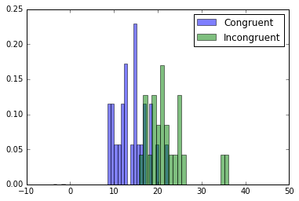

```python
pyplot.hist(congruent, \
         bins_cong, \
         normed = 1, \
         alpha = 0.5, \
         label = 'Congruent')
pyplot.hist(incongruent, \
         bins_incong, \
         normed = 1, \
         alpha = 0.5, \
         label = 'Incongruent')
pyplot.legend(loc = 'upper right')
pyplot.show()
```

##### Relevant normal distributions

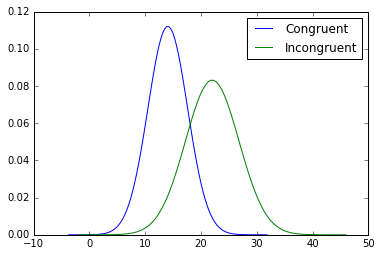

```python
pyplot.plot(space_cong,mlab.normpdf(space_cong, \
                                 mean_cong, \
                                 stdev_cong), \
                                 label = 'Congruent')
pyplot.plot(space_incong,mlab.normpdf(space_incong, \
                                   mean_incong, \
                                   stdev_incong), \
                                   label = 'Incongruent')
pyplot.legend(loc = 'upper right')
pyplot.show()
```

##### Observations

The fact that there is not a great overlap between the two histograms and that the mode of the congruent set takes a value about 27% lower than that of the mode of the incongruent set suggest that under the congruent condition the participants performed in general better.

Also from the equivalent normal distributions we can see that under the incongruent condition the performance of the participants varied more than under the congruent one.

**5) Now, perform the statistical test and report your results. What is your confidence level and your critical statistic value? Do you reject the null hypothesis or fail to reject it? Come to a conclusion in terms of the experiment task. Did the results match up with your expectations?**

Since we only have two dependent samples and we don't know the population parameters $(\mu,\sigma)$ I am going to use a t-test.

The two samples have size $n=24$ and $n-1=23$ degrees of freedom. The t critical values for $p < 0.05, 0.01$ & $0.001$ are $1.714, 2.500$ & $3.485$ respectively.

The t-statistic can be calculated from the following formula: $t=\frac{\mu_{Q} - \mu_{A}}{\frac{S}{\sqrt{n}}}$

```python
t_statistic = point_estimate/(stdev_diff/np.sqrt(24))
print 'The t-statistic of the samples is %.2f and it is higher than the \
t critical value for p < 0.001 which is equal to 3.485' % t_statistic
```

```
The t-statistic of the samples is 8.02 and it is higher than the t critical value for p < 0.001 which is equal to 3.485
```

```python
from scipy import stats
stats.ttest_rel(incongruent,congruent)
```

```
Ttest_relResult(statistic=8.0207069441099588, pvalue=4.1030005857111556e-08)
```

The results for the t statistic suggest that I should reject the null hypothesis and accept the alternative, which is something expected from the nature of the task.

**6) Optional: What do you think is responsible for the effects observed? Can you think of an alternative or similar task that would result in a similar effect? Some research about the problem will be helpful for thinking about these two questions!**

Under the congruent condition the participants need to do a task that requires no thinking. It is just enough to read out loud the words as fast as possible. Thus what is measured is the speed with which the participants can read out loud a set of words.

However, under the incogruent condition the participant has to actually do three tasks. First to actively suppress the signal coming to the brain from reading a word, second to recognise the color of the letters and third to read it out loud. This is clearly more difficult to do than just reading the words and consequently it takes more time to perform.

Another task can be a video game where the player has to shoot various targets. If first the player has to shoot every target and afterwards he/she has to shoot only a specific set of them, then the results (for untrained players) are likely to be similar with those of the stroop effect.

In general, every task that an untrained participant has to do at first something automatized and afterwards something similar which requires some extra brain activity is likely to have similar results with the stroop effect.

## References

Stroop effect: https://en.wikipedia.org/wiki/Stroop_effect

Numpy documentation: https://docs.scipy.org/doc/

Numpy std corrected: http://stackoverflow.com/questions/27600207/why-does-numpy-std-give-a-different-result-to-matlab-std

Matplotlib documentation: http://matplotlib.org/contents.html

Scipy t-test: https://docs.scipy.org/doc/scipy/reference/generated/scipy.stats.ttest_rel.html

t-table: https://s3.amazonaws.com/udacity-hosted-downloads/t-table.jpg